# Data_Cleaning_and_Preprocessing

**Data Cleaning and Preprocessing**

**Steven Archuleta**  
Interview Candidate  
Research Data Analyst I/II

- CDSS (California Department of Social Services)
- RADD (Research Automation Data Division)
- RDI (Research Data Insights Branch)
- EARS (Exploratory Analysis & Research Section)
- AM (Analysis & Modelling Unit)

**TABLE OF CONTENTS**

| . | . | . | . |  |
| --- | --- | --- | --- | --- |
| 1. Libraries and Packages | 2. Load Data | 3. Shape of Data Frame | 4. Sample of DataFrame |  |
| 5. Feature Names | 6. Info & Datatypes | 7. Missing Values | 8. Duplicate Records |  |
| 9. Unique Values | 10. Split Datasets | 11. Outliers | 12. Box Plots | 13. Bar Plots |
| 13. ECDF Plot | 14. ECDF Plot | 15. Statistical Summary | 16. Z-Score Scaling |  |

### Import Libraries and Packages

#### OBSERVATION

These are collections of modules that provide pre-written code to perform common tasks, easing the process of programming and increasing the efficiency of data cleaning, preprocessing, and analysis in Python.

1. **Pandas:**

   Pandas is a popular data manipulation library in Python that provides flexible data structures that make working with structured data fast and easy.
   - Alias: pandas as pd

   </li>
2. **Numpy:**

   Numpy is a Python library used for numerical computations and working with arrays, including mathematical, logical, shape manipulation, sorting, selecting, I/O, discrete Fourier transforms, basic linear algebra, basic statistical operations, random simulation and much more.
   - Alias: numpy as np

   </li>
3. **MatPlotLib:**

   Matplotlib is a plotting library for Python and its numerical mathematics extension, NumPy. It provides an object-oriented API for embedding plots into applications.
   - Alias: matplotlib.pyplot as plt

   </li>
4. **Seaborn:**

   Seaborn is a Python data visualization library based on Matplotlib. It provides a high-level interface for creating attractive and informative statistical graphics.
   - Alias: seaborn as sns

   </li>
5. **Datetime:**

   Datetime is a module in the Python standard library that supplies classes for manipulating dates and times, such as obtaining the current date and time, formatting or parsing dates, and performing time arithmetic.
   - No Alias

   </li>
6. **Math:**

   The Math module is a standard module in Python that provides mathematical functions. These functions cannot be used with complex numbers; use the functions of the same name from the cmath module if you require support for complex numbers.
   - No Alias

   </li>
7. **MissingNo:**

   MissingNo is a Python library that provides a small toolset of flexible and easy-to-use missing data visualizations and utilities that allow you to get a quick visual summary of the completeness (or lack thereof) of your dataset.
   - Alias: missingno as msno

   </li>
8. **StandardScaler:**

   StandardScaler is a feature scaling method in the Scikit-Learn library in Python that standardizes features by removing the mean and scaling to unit variance. It is a common requirement for many machine learning estimators.
   - No Alias:

   </li>
9. **Regular Expressions:**

   Regular expressions (often abbreviated as "regex") are sequences of characters that form a search pattern. They are used in Python, and many other programming languages, for text searching and text manipulation. The 're' module in Python provides support for regular expressions.
   - Alias: re

   </li>
10. **MinMaxScaler:**

    MinMaxScaler is another feature scaling method from the Scikit-Learn library in Python. It scales and translates each feature individually such that it is in the given range on the training set, e.g. between zero and one.
    - No Alias

    </li>
11. **OneHotEncoder:**

    OneHotEncoder is a function in the Scikit-Learn library in Python that is used to convert categorical data, or text data, into numbers, which the model can understand.
    - No Alias

    </li>
12. **LabelEncoder:**

    LabelEncoder is a utility class to help normalize labels such that they contain only values between 0 and n_classes-1, where n is the number of distinct labels. It can also be used to transform non-numerical labels to numerical labels, which is an essential part of machine learning since many algorithms do not support non-numerical values.
    - No Alias

    </li>
13. **Warnings:**

    The warnings module in Python's standard library is used when you want to warn users of your program about a certain condition (that you specified) instead of raising an exception. It's typically used for deprecations, or changes in a function or behavior.
    - No Alias

    </li>
14. **Display:**

    The 'display' function is a part of the IPython.display module in Python. It is used for displaying outputs in different formats within Jupyter notebook cells, such as HTML, JSON, PNG, JPEG, SVG, and LaTeX.
    - No Alias

```python
# ===================================================
# This will automatically make the Python code more
# structured (good coding practice)
# from IPython import get_ipython

# ipython = get_ipython()
# if "nb_black" not in ipython.extension_manager.loaded:
#    %load_ext nb_black
# ====================================================
import pandas as pd
import numpy as np
import matplotlib.pyplot as plt
import seaborn as sns
sns.set()
import datetime
import math
import missingno as msno
import re
from sklearn.preprocessing import StandardScaler
from sklearn.preprocessing import MinMaxScaler
from sklearn.preprocessing import OneHotEncoder
from sklearn.preprocessing import LabelEncoder
import warnings
warnings.filterwarnings("ignore")

# ====================================================
# Removes the limit for the number of displayed columns
pd.set_option("display.max_columns", None)
# Sets the limit for the number of displayed rows
pd.set_option("display.max_rows", 200)
# ====================================================

# ====================================================
## Create a function to display side by side
from IPython.display import display_html


def display_side_by_side(*args):
    html_str = ""
    for df in args:
        html_str += df.to_html() + "&nbsp;&nbsp;&nbsp;"
    display_html(html_str.replace("table", 'table style="display:inline"'), raw=True)


# ====================================================
```

### Load raw dataset(s)

🔼

```python
from google.colab import drive

# Mount Google Drive
drive.mount('/content/drive')

# Path to the folder containing the CSV files in your Google Drive
folder_path = '/content/drive/MyDrive/RDA_Interview_Exercise/data/'

# File names
claims_filename = 'claims.csv'
reimbursements_filename = 'reimbursements.csv'

# Load the CSV files
claims_raw_df = pd.read_csv(folder_path + claims_filename)
reimbursements_raw_df = pd.read_csv(folder_path + reimbursements_filename)
```

### Shape of Dataframe(s)

🔼

```python
# Because of possible imputations below, reassign the original data to claims_copy
claims_copy = claims_raw_df.copy()
# Because of possible imputations below,reassign the original data to reimbursements_copy
reimbursements_copy = reimbursements_raw_df.copy()

# Create the summary dataframes
claims_summary_df = pd.DataFrame(
    {"Rows": [claims_copy.shape[0]], "Columns": [claims_copy.shape[1]]},
    index=["claims_copy"],
)
reimbursements_summary_df = pd.DataFrame(
    {"Rows": [reimbursements_raw_df.shape[0]], "Columns": [reimbursements_raw_df.shape[1]]},
    index=["reimbursements_raw_df"],
)

# Call function to display the two dataframes side by side
display_side_by_side(claims_summary_df, reimbursements_summary_df)
```

|  | Rows | Columns |
| --- | --- | --- |
| claims_copy | 345587 | 7 |

|  | Rows | Columns |
| --- | --- | --- |
| reimbursements_raw_df | 120020 | 14 |

### Display Random Sample of DataFrame(s)

🔼

```python
# Create a copy of the claims data
claims_copy = claims_raw_df.copy()

# Set the random seed
np.random.seed(1)

# Obtain a sample of 10 rows from the claims DataFrame
claims_sample = claims_copy.sample(n=10, replace=False)

# Display the claims sample
display(claims_sample)
```

|  | caseID | cardID | case_county | client_language | retail_zip | adj_amt | transact_date |
| --- | --- | --- | --- | --- | --- | --- | --- |
| 164864 | 1cbb07a5c4e969d6e72e62ba250aa0795ec3f40e0377b5... | 1748961109e758f7d228b02cd8dbf816474caf7b7b29f2... | 10 | English | 95610.0 | 177.73 | 2022-11-05 |
| 184512 | ed63103eb84d07ea4387c10ae5a834a564699f1a3166f1... | 6e7bc460f7af818618a87ded8595d6fe44aaf2975259dc... | 41 | English | NaN | 310.88 | 2022-11-18 |
| 147716 | 68f61ae38af3f05c5f02ce2dd26091d5d3a0302fb55f99... | e566847eacfae446ca356681d28c8314940e0000ad08d4... | 1 | English | NaN | 51.53 | 2022-10-20 |
| 317751 | b892c96af5a79d86443b682f29abf5cc1215db7c6aaaf9... | 4426027906c9ee8b1208d3e14ec2fff2aaee0d507d2522... | 43 | English | NaN | 199.90 | 2023-02-10 |
| 189435 | e7908b9703c394c96132f6bdaeaf610262c3efc4bf4c6e... | 1a9914588e3b9f93f5a9daf7fd24c93278bede62f60ff3... | 15 | English | NaN | 18.38 | 2022-11-27 |
| 80759 | 661e905c3ea6103e158f8ad693c1867757f084c1d779a1... | 065f4c48576f8fadaed842d82d917f33c39844c32217fe... | 19 | English | NaN | 860.00 | 2022-09-01 |
| 165606 | 85e5b39af065fe28063eab7861d2dfeaa94df33a40a2f4... | 1d8a4de791ad7131cf73c7d70deea575d67034fad72044... | 7 | English | NaN | 77.96 | 2022-11-02 |
| 130947 | b1a6997ef91493bc7570bfe9841a15e3bd533bb1f1e9fb... | a7699c15796b66b2cd4b3d612f456c8cc0ad4419f3ce97... | 19 | English | NaN | 14.00 | 2022-10-03 |
| 98178 | 5f2acb8f8f00428341aaf9b791acd5dd628978aaadb142... | 743e3424e825b296438f15966f31dca111c494d017b32f... | 19 | English | 11221 | 298.00 | 2022-09-12 |
| 268004 | ad3308dc3c4e44d39474593709f3656ccfbef3c835e553... | b57210b493e316e38d5fadb95fa1cef4389f0a7c500755... | 10 | English | 48071 | 233.00 | 2023-01-07 |

```python
# Create a copy of the reimbursements data
reimbursements_copy = reimbursements_raw_df.copy()

# Set the random seed
np.random.seed(1)

# Obtain a sample of 10 rows from the reimbursements DataFrame
reimbursements_sample = reimbursements_copy.sample(n=10, replace=False)

# Display the reimbursements sample
display(reimbursements_sample)
```

|  | caseID | cardID_1 | cardID_2 | cardID_3 | cardID_4 | case_county | client_language_1 | client_language_2 | client_language_3 | client_language_4 | benefit_amount | benefit_year | benefit_month | pay_date |
| --- | --- | --- | --- | --- | --- | --- | --- | --- | --- | --- | --- | --- | --- | --- |
| 39513 | e704b14bbd5c5d00fd64e13667617aea3300a53a916414... | 1bacf006f739f1ecf4fa01d68a403207fa1c3beda52afe... | 96b33fe9fa19a7b2f0bc1389d9802ce7cc44aa2832909b... | c47d39edb31bc8a8ae6e113bbe9f305c1fe075d476dc0d... | c47d39edb31bc8a8ae6e113bbe9f305c1fe075d476dc0d... | 19.0 | Spanish | Spanish | NaN | NaN | 346.00 | 2021 | 10 | 2022-10-27 |
| 51375 | 1f0e71cfd7ac923c99a5ca62c88c86ed68e518c73827f5... | a91c38be846e6c0142f5e74161542111009fb07d3f7bf7... | c47d39edb31bc8a8ae6e113bbe9f305c1fe075d476dc0d... | c47d39edb31bc8a8ae6e113bbe9f305c1fe075d476dc0d... | c47d39edb31bc8a8ae6e113bbe9f305c1fe075d476dc0d... | 36.0 | English | NaN | NaN | NaN | 52.00 | 2022 | 10 | 2022-12-06 |
| 25412 | ba756c6c36ab5b7eaa36ff7bdd23890f860eb72bf5295e... | 2725d0e8ea9ec154bb5b074dce6c8eb6cc26a63c7bfa96... | c47d39edb31bc8a8ae6e113bbe9f305c1fe075d476dc0d... | c47d39edb31bc8a8ae6e113bbe9f305c1fe075d476dc0d... | c47d39edb31bc8a8ae6e113bbe9f305c1fe075d476dc0d... | 19.0 | Spanish | NaN | NaN | NaN | 920.00 | 2022 | 9 | 2022-09-16 |
| 603 | 120569724bf4161b8f0f72fd46301c973eaff3c2680eb4... | 52901cf8ba4a3b522ba2d006c96efc0d7c014a5c37cfb4... | c47d39edb31bc8a8ae6e113bbe9f305c1fe075d476dc0d... | c47d39edb31bc8a8ae6e113bbe9f305c1fe075d476dc0d... | c47d39edb31bc8a8ae6e113bbe9f305c1fe075d476dc0d... | 37.0 | English | NaN | NaN | NaN | 43.81 | 2022 | 6 | 2022-06-21 |
| 19957 | 785598013719b953e1934a3210c415394bb290dc20a9cb... | f91492fdd1bfc6cf1e3a3d7b93c7b50285cbc0d9f9fe24... | c47d39edb31bc8a8ae6e113bbe9f305c1fe075d476dc0d... | c47d39edb31bc8a8ae6e113bbe9f305c1fe075d476dc0d... | c47d39edb31bc8a8ae6e113bbe9f305c1fe075d476dc0d... | 19.0 | English | NaN | NaN | NaN | 1340.00 | 2022 | 6 | 2022-08-25 |
| 117441 | 72f95a93f995fad64f747501bb649835750c05840b772c... | b471f5ad84b43a0da08da370a6490cdbe457f75aee761a... | c47d39edb31bc8a8ae6e113bbe9f305c1fe075d476dc0d... | c47d39edb31bc8a8ae6e113bbe9f305c1fe075d476dc0d... | c47d39edb31bc8a8ae6e113bbe9f305c1fe075d476dc0d... | 19.0 | English | NaN | NaN | NaN | 398.00 | 2023 | 2 | 2023-03-03 |
| 115054 | e3adae88249f524d3a2ef3eeb14d91157946bdb2a1f4a7... | 5dba2db18756ed2edff6a97d5c1992de4e536677b10dfb... | c47d39edb31bc8a8ae6e113bbe9f305c1fe075d476dc0d... | c47d39edb31bc8a8ae6e113bbe9f305c1fe075d476dc0d... | c47d39edb31bc8a8ae6e113bbe9f305c1fe075d476dc0d... | 50.0 | English | NaN | NaN | NaN | 1000.00 | 2023 | 3 | 2023-03-06 |
| 42613 | b78423b6ca5a629c1334bbe072e022667476a5af023ad9... | 76b7c6cf042dcbb53ca0deae601a0d5e086b889267ed98... | c47d39edb31bc8a8ae6e113bbe9f305c1fe075d476dc0d... | c47d39edb31bc8a8ae6e113bbe9f305c1fe075d476dc0d... | c47d39edb31bc8a8ae6e113bbe9f305c1fe075d476dc0d... | 19.0 | English | NaN | NaN | NaN | 1283.00 | 2022 | 11 | 2022-11-15 |
| 28321 | 8d76bbf86917f7346b4a40845042f3aea18829d2de1f78... | 9ded8b30f53e02b5ec5b7029cb955c37b7d1e37c035187... | c47d39edb31bc8a8ae6e113bbe9f305c1fe075d476dc0d... | c47d39edb31bc8a8ae6e113bbe9f305c1fe075d476dc0d... | c47d39edb31bc8a8ae6e113bbe9f305c1fe075d476dc0d... | 34.0 | Eastern Armenian | NaN | NaN | NaN | 500.00 | 2022 | 9 | 2022-09-23 |
| 2481 | d530d22a7f3c9ffa8a97556346954b3f44bc03f65207e9... | ce18567ea84f91142ba2e5039c1727393592ee05274fa4... | c47d39edb31bc8a8ae6e113bbe9f305c1fe075d476dc0d... | c47d39edb31bc8a8ae6e113bbe9f305c1fe075d476dc0d... | c47d39edb31bc8a8ae6e113bbe9f305c1fe075d476dc0d... | 43.0 | English | NaN | NaN | NaN | 250.00 | 2022 | 4 | 2022-06-27 |

### Feature Names

🔼

```python
# Features
df1 = pd.DataFrame(data={"Claims Features": claims_copy.columns})
df2 = pd.DataFrame(data={"Reimbursements Features": reimbursements_copy.columns})

# Call function to display the two dataframes side by side
display_side_by_side(df1, df2)
```

|  | Claims Features |
| --- | --- |
| 0 | caseID |
| 1 | cardID |
| 2 | case_county |
| 3 | client_language |
| 4 | retail_zip |
| 5 | adj_amt |
| 6 | transact_date |

|  | Reimbursements Features |
| --- | --- |
| 0 | caseID |
| 1 | cardID_1 |
| 2 | cardID_2 |
| 3 | cardID_3 |
| 4 | cardID_4 |
| 5 | case_county |
| 6 | client_language_1 |
| 7 | client_language_2 |
| 8 | client_language_3 |
| 9 | client_language_4 |
| 10 | benefit_amount |
| 11 | benefit_year |
| 12 | benefit_month |
| 13 | pay_date |

### DataFrame Info and Datatypes

#### OBSERVATIONS

1. **Claims Info:**

   Change the following data types.
   - transact_date: from object to datetime
   - case_county: from integer to categorical
   - client_langage: from object to categorical

   </ul> </li>
   - **Reimbursement Info:**

```python
claims_copy.info()
```

```
<class 'pandas.core.frame.DataFrame'>
RangeIndex: 345587 entries, 0 to 345586
Data columns (total 7 columns):
 #   Column           Non-Null Count   Dtype
---  ------           --------------   -----
 0   caseID           345587 non-null  object
 1   cardID           345587 non-null  object
 2   case_county      345587 non-null  int64
 3   client_language  345587 non-null  object
 4   retail_zip       94839 non-null   object
 5   adj_amt          345587 non-null  float64
 6   transact_date    345587 non-null  object
dtypes: float64(1), int64(1), object(5)
memory usage: 18.5+ MB
```

```python
reimbursements_copy.info()
```

```
<class 'pandas.core.frame.DataFrame'>
RangeIndex: 120020 entries, 0 to 120019
Data columns (total 14 columns):
 #   Column             Non-Null Count   Dtype
---  ------             --------------   -----
 0   caseID             120020 non-null  object
 1   cardID_1           120020 non-null  object
 2   cardID_2           120020 non-null  object
 3   cardID_3           120020 non-null  object
 4   cardID_4           120020 non-null  object
 5   case_county        120015 non-null  float64
 6   client_language_1  120015 non-null  object
 7   client_language_2  32824 non-null   object
 8   client_language_3  8109 non-null    object
 9   client_language_4  2426 non-null    object
 10  benefit_amount     120020 non-null  float64
 11  benefit_year       120020 non-null  int64
 12  benefit_month      120020 non-null  int64
 13  pay_date           120020 non-null  object
dtypes: float64(2), int64(2), object(10)
memory usage: 12.8+ MB
```

```python
# Convert Datatypes
claims_copy['case_county'] = claims_copy['case_county'].astype('category')
reimbursements_copy['case_county'] = reimbursements_copy['case_county'].astype('category')

claims_copy['transact_date'] = pd.to_datetime(claims_copy['transact_date'])

reimbursements_copy['pay_date'] = pd.to_datetime(reimbursements_copy['pay_date'])

reimbursements_copy['benefit_year'] = reimbursements_copy['benefit_year'].astype('category')
reimbursements_copy['benefit_month'] = reimbursements_copy['benefit_month'].astype('category')

claims_copy['client_language'] = claims_copy['client_language'].astype('category')
reimbursements_copy['client_language_1'] = reimbursements_copy['client_language_1'].astype('category')
reimbursements_copy['client_language_2'] = reimbursements_copy['client_language_2'].astype('category')
reimbursements_copy['client_language_3'] = reimbursements_copy['client_language_3'].astype('category')
reimbursements_copy['client_language_4'] = reimbursements_copy['client_language_4'].astype('category')

claims_copy['retail_zip'] = claims_copy['retail_zip'].astype('category')
reimbursements_copy['case_county'] = reimbursements_copy['case_county'].astype('category')

# Verify the updated data types
print(claims_copy.info())
print(reimbursements_copy.info())
```

```
<class 'pandas.core.frame.DataFrame'>
RangeIndex: 345587 entries, 0 to 345586
Data columns (total 7 columns):
 #   Column           Non-Null Count   Dtype
---  ------           --------------   -----
 0   caseID           345587 non-null  object
 1   cardID           345587 non-null  object
 2   case_county      345587 non-null  category
 3   client_language  345587 non-null  category
 4   retail_zip       94839 non-null   category
 5   adj_amt          345587 non-null  float64
 6   transact_date    345587 non-null  datetime64[ns]
dtypes: category(3), datetime64[ns](1), float64(1), object(2)
memory usage: 12.0+ MB
None
<class 'pandas.core.frame.DataFrame'>
RangeIndex: 120020 entries, 0 to 120019
Data columns (total 14 columns):
 #   Column             Non-Null Count   Dtype
---  ------             --------------   -----
 0   caseID             120020 non-null  object
 1   cardID_1           120020 non-null  object
 2   cardID_2           120020 non-null  object
 3   cardID_3           120020 non-null  object
 4   cardID_4           120020 non-null  object
 5   case_county        120015 non-null  category
 6   client_language_1  120015 non-null  category
 7   client_language_2  32824 non-null   category
 8   client_language_3  8109 non-null    category
 9   client_language_4  2426 non-null    category
 10  benefit_amount     120020 non-null  float64
 11  benefit_year       120020 non-null  category
 12  benefit_month      120020 non-null  category
 13  pay_date           120020 non-null  datetime64[ns]
dtypes: category(7), datetime64[ns](1), float64(1), object(5)
memory usage: 7.2+ MB
None
```

### Missing Values

#### OBSERVATIONS

Percentage of missing values per feature.

1. **Claims DataFrame:**

```python
# Print the total number of missing values in claims_copy
print("Number of total missing values in claims_copy:", claims_copy.isnull().sum().sum())

# Print the total number of missing values in reimbursements_copy
print("Number of total missing values in reimbursements_copy:", reimbursements_copy.isnull().sum().sum())
```

```
Number of total missing values in claims_copy: 250748
Number of total missing values in reimbursements_copy: 316711
```

```python
# Check for missing values in each column of claims_copy
print("Missing values in claims_copy:")
print(claims_copy.isnull().any())
print()

# Check for missing values in each column of reimbursements_copy
print("Missing values in reimbursements_copy:")
print(reimbursements_copy.isnull().any())
```

```
Missing values in claims_copy:
caseID             False
cardID             False
case_county        False
client_language    False
retail_zip          True
adj_amt            False
transact_date      False
dtype: bool

Missing values in reimbursements_copy:
caseID               False
cardID_1             False
cardID_2             False
cardID_3             False
cardID_4             False
case_county           True
client_language_1     True
client_language_2     True
client_language_3     True
client_language_4     True
benefit_amount       False
benefit_year         False
benefit_month        False
pay_date             False
dtype: bool
```

```python
# List columns with missing values in claims_copy
print("Columns with missing values in claims_copy:")
missing_columns_claims = claims_copy.columns[claims_copy.isnull().any()]
print(missing_columns_claims)
print()

# List columns with missing values in reimbursements_copy
print("Columns with missing values in reimbursements_copy:")
missing_columns_reimbursements = reimbursements_copy.columns[reimbursements_copy.isnull().any()]
print(missing_columns_reimbursements)
```

```
Columns with missing values in claims_copy:
Index(['retail_zip'], dtype='object')

Columns with missing values in reimbursements_copy:
Index(['case_county', 'client_language_1', 'client_language_2',
       'client_language_3', 'client_language_4'],
      dtype='object')
```

```python
# Number of missing values by column in claims_copy
print("Number of missing values by column in claims_copy:")
print(claims_copy.isnull().sum())
print()

# Number of missing values by column in reimbursements_copy
print("Number of missing values by column in reimbursements_copy:")
print(reimbursements_copy.isnull().sum())
```

```
Number of missing values by column in claims_copy:
caseID                  0
cardID                  0
case_county             0
client_language         0
retail_zip         250748
adj_amt                 0
transact_date           0
dtype: int64

Number of missing values by column in reimbursements_copy:
caseID                    0
cardID_1                  0
cardID_2                  0
cardID_3                  0
cardID_4                  0
case_county               5
client_language_1         5
client_language_2     87196
client_language_3    111911
client_language_4    117594
benefit_amount            0
benefit_year              0
benefit_month             0
pay_date                  0
dtype: int64
```

```python
# Calculate the percentage of missing values for columns with missing data in claims_copy
missing_columns_claims = claims_copy.columns[claims_copy.isnull().any()]
missing_percentage_claims = claims_copy[missing_columns_claims].isnull().sum() / len(claims_copy) * 100
print("Percentage of missing values in claims_copy:")
print(missing_percentage_claims)

print("\n")

# Calculate the percentage of missing values for columns with missing data in reimbursements_copy
missing_columns_reimbursements = reimbursements_copy.columns[reimbursements_copy.isnull().any()]
missing_percentage_reimbursements = reimbursements_copy[missing_columns_reimbursements].isnull().sum() / len(reimbursements_copy) * 100
print("Percentage of missing values in reimbursements_copy:")
print(missing_percentage_reimbursements)
```

```
Percentage of missing values in claims_copy:
retail_zip    72.557127
dtype: float64


Percentage of missing values in reimbursements_copy:
case_county           0.004166
client_language_1     0.004166
client_language_2    72.651225
client_language_3    93.243626
client_language_4    97.978670
dtype: float64
```

```python
# Total number of missing values in case_county
missing_count = reimbursements_copy['case_county'].isnull().sum()
print("Total number of missing values in case_county:", missing_count)

# Mode of case_county
mode_county = reimbursements_copy['case_county'].mode()[0]
print("Mode of case_county:", mode_county)
```

```
Total number of missing values in case_county: 5
Mode of case_county: 19.0
```

```python
# DO NOT RUN
# Impute mode for case_county
# reimbursements_copy['case_county'].fillna(mode_county, inplace=True)
```

```python
# Drop rows with missing values in case_county
reimbursements_copy.dropna(subset=['case_county'], inplace=True)
```

```python
# Total number of missing values in client_language_1
missing_count = reimbursements_raw_df['client_language_1'].isnull().sum()
print("Total number of missing values in client_language_1:", missing_count)

# Mode of client_language_1
mode_language = reimbursements_raw_df['client_language_1'].mode()[0]
print("Mode of client_language_1:", mode_language)
```

```
Total number of missing values in client_language_1: 5
Mode of client_language_1: English
```

```python
# DO NOT RUN
# Impute mode for client_language_1
# reimbursements_copy['client_language_1'].fillna(mode_language, inplace=True)
```

```python
# Drop rows with missing values in client_language_1
reimbursements_copy.dropna(subset=['client_language_1'], inplace=True)
```

```python
# Total number of missing values in retail_zip
missing_count = claims_copy['retail_zip'].isnull().sum()
print("Total number of missing values in retail_zip:", missing_count)

# Mode of retail_zip
mode_zip = claims_copy['retail_zip'].mode()[0]
print("Mode of retail_zip:", mode_zip)

# Impute mode for retail_zip
claims_copy['retail_zip'].fillna(mode_zip, inplace=True)
```

```
Total number of missing values in retail_zip: 250748
Mode of retail_zip: 11221
```

```python
# Total number of missing values in client_language_2
missing_count_2 = reimbursements_copy['client_language_2'].isnull().sum()
print("Total number of missing values in client_language_2:", missing_count_2)

# Mode of client_language_2
mode_language_2 = reimbursements_copy['client_language_2'].mode()[0]
print("Mode of client_language_2:", mode_language_2)

# Impute mode for client_language_2
reimbursements_copy['client_language_2'].fillna(mode_language_2, inplace=True)

# Total number of missing values in client_language_3
missing_count_3 = reimbursements_copy['client_language_3'].isnull().sum()
print("Total number of missing values in client_language_3:", missing_count_3)

# Mode of client_language_3
mode_language_3 = reimbursements_copy['client_language_3'].mode()[0]
print("Mode of client_language_3:", mode_language_3)

# Impute mode for client_language_3
reimbursements_copy['client_language_3'].fillna(mode_language_3, inplace=True)

# Total number of missing values in client_language_4
missing_count_4 = reimbursements_copy['client_language_4'].isnull().sum()
print("Total number of missing values in client_language_4:", missing_count_4)

# Mode of client_language_4
mode_language_4 = reimbursements_copy['client_language_4'].mode()[0]
print("Mode of client_language_4:", mode_language_4)

# Impute mode for client_language_4
reimbursements_copy['client_language_4'].fillna(mode_language_4, inplace=True)
```

```
Total number of missing values in client_language_2: 87191
Mode of client_language_2: English
Total number of missing values in client_language_3: 111906
Mode of client_language_3: English
Total number of missing values in client_language_4: 117589
Mode of client_language_4: English
```

```python
# VERIFICATION
# Print the total number of missing values in claims_copy
print("Number of total missing values in claims_copy:", claims_copy.isnull().sum().sum())

# Print the total number of missing values in reimbursements_copy
print("Number of total missing values in reimbursements_copy:", reimbursements_copy.isnull().sum().sum())
```

```
Number of total missing values in claims_copy: 0
Number of total missing values in reimbursements_copy: 0
```

### Duplicate Records

#### OBSERVATIONS

Check for duplicate rows/records/data_objects/observations

1. **Claims Database:**

   There are 27,860 duplicate records in the claims_copy dataframe.

   The duplicate records are shown, and each record includes the values of all columns.

   </li>
2. **Reimbursements Database:**

   There are 2,127 duplicate records in the reimbursements_copy dataframe

   The duplicate records are shown, and each record includes the values of all columns.

```python
# Check for duplicates in claims_copy
duplicate_rows_claims = claims_copy.duplicated(keep=False)

if duplicate_rows_claims.any():
    # Get the duplicate records
    duplicate_records_claims = claims_copy[duplicate_rows_claims]

    # Count the number of duplicate records
    num_duplicates_claims = duplicate_records_claims.shape[0]

    print(f"There are {num_duplicates_claims} duplicate records in claims_copy after dropping duplicates:")
    print(duplicate_records_claims)
else:
    print("There are no duplicate records in claims_copy after dropping duplicates.")
```

```
There are 27860 duplicate records in claims_copy after dropping duplicates:
                                                   caseID  \
15      c6980db6b4184e196746241c253d291599db4619c916d9...
20      99277b7e126cfd915ee60e09147aeb6df43be4ffeb38a2...
21      99277b7e126cfd915ee60e09147aeb6df43be4ffeb38a2...
37      c6980db6b4184e196746241c253d291599db4619c916d9...
53      f1b83ab34da13a59eb1165ae905ce6a267af4e323a3737...
...                                                   ...
345070  da6275e73fcac32722ceb9234f3aadd16a9c9c11ada88b...
345345  390c8b763912ef2da3548b390da583d05e25b8354d48a6...
345346  390c8b763912ef2da3548b390da583d05e25b8354d48a6...
345468  f5c7158427dde1a34d35719021f65a80964da2a71c55d4...
345469  f5c7158427dde1a34d35719021f65a80964da2a71c55d4...

                                                   cardID case_county  \
```

[output cut: 26 more lines]

```python
# Drop duplicate rows in claims_copy
claims_copy.drop_duplicates(inplace=True)
```

```python
# Check for duplicates in reimbursements_copy
duplicate_rows_reimbursements = reimbursements_copy.duplicated(keep=False)

if duplicate_rows_reimbursements.any():
    # Get the duplicate records
    duplicate_records_reimbursements = reimbursements_copy[duplicate_rows_reimbursements]

    # Count the number of duplicate records
    num_duplicates_reimbursements = duplicate_records_reimbursements.shape[0]

    print(f"There are {num_duplicates_reimbursements} duplicate records in reimbursements_copy after dropping duplicates:")
    print(duplicate_records_reimbursements)
else:
    print("There are no duplicate records in reimbursements_copy after dropping duplicates.")
```

```
There are 2127 duplicate records in reimbursements_copy after dropping duplicates:
                                                   caseID  \
162     d643a66b695a2695da62274a618756153f49dc7fb1ec43...
177     d643a66b695a2695da62274a618756153f49dc7fb1ec43...
178     d643a66b695a2695da62274a618756153f49dc7fb1ec43...
181     d643a66b695a2695da62274a618756153f49dc7fb1ec43...
414     ad1b9616841b41fe050431b0c4368b1345b833dd3b5581...
...                                                   ...
119984  a0be9992c0774af2b43655a8b830201f8bebf29d769d4b...
119995  fb189c614a5613adaf540d95b568d8743e005faaf156cc...
120002  fb189c614a5613adaf540d95b568d8743e005faaf156cc...
120007  38e1cec9ab99316895e23148f0fa765ecc73b17f71abce...
120010  fb189c614a5613adaf540d95b568d8743e005faaf156cc...

                                                 cardID_1  \
```

[output cut: 78 more lines]

```python
# Drop duplicate rows in reimbursements_copy
reimbursements_copy.drop_duplicates(inplace=True)
```

```python
# VERIFICATION
# Check for duplicates in claims_copy
duplicate_rows_claims = claims_copy.duplicated(keep=False)

if duplicate_rows_claims.any():
    # Get the duplicate records
    duplicate_records_claims = claims_copy[duplicate_rows_claims]

    # Count the number of duplicate records
    num_duplicates_claims = duplicate_records_claims.shape[0]

    print(f"There are {num_duplicates_claims} duplicate records in claims_copy:")
    print(duplicate_records_claims)
else:
    print("There are no duplicate records in claims_copy.")
```

```
There are no duplicate records in claims_copy.
```

```python
# VERIFICATION
# Check for duplicates in reimbursements_copy
duplicate_rows_reimbursements = reimbursements_copy.duplicated(keep=False)

if duplicate_rows_reimbursements.any():
    # Get the duplicate records
    duplicate_records_reimbursements = reimbursements_copy[duplicate_rows_reimbursements]

    # Count the number of duplicate records
    num_duplicates_reimbursements = duplicate_records_reimbursements.shape[0]

    print(f"There are {num_duplicates_reimbursements} duplicate records in reimbursements_copy:")
    print(duplicate_records_reimbursements)
else:
    print("There are no duplicate records in reimbursements_copy.")
```

```
There are no duplicate records in reimbursements_copy.
```

### Unique Values

#### OBSERVATIONS

1. **Claims DataFrame:**

   Count of unique values in:
   - caseID: 138,182 -- multiple claims can be associated with the same case.
   - cardID: 149,710 -- multiple claims can be associated with the same card
   - case_county: 58 -- claims are distributed across different counties.
   - client_language: 14 -- individuals with different primary languages are making claims.
   - retail_zip: 5,287 -- claim thefts are associated with various retail locations.
   - adj_amt: 50,599 -- a probable wide range of reimbursement amounts.
   - transact_date: 303 -- claims are claims made on different dates thorughout the year.

   </li>
2. **Reimbursements DataFrame:**

```python
# =============================
# TOTAL UNIQUE VALUES BY COLUMN
# =============================
display(
    pd.DataFrame(data={"Unique Number of Claims Values by Column": claims_copy.nunique()})
)
print("\n")
display(
    pd.DataFrame(
        data={"Unique Number of Reimbursements Values by Column": reimbursements_copy.nunique()}
    )
)
print("\n")

# =============================
# TOTAL UNIQUE VALUES BY COLUMN
# =============================
def return_unique_values(data_frame):
    unique_dataframe = pd.DataFrame()
    unique_dataframe["Features"] = data_frame.columns
    uniques = []
    for col in data_frame.columns:
        u = data_frame[col].nunique()
        uniques.append(u)
    unique_dataframe["Uniques"] = uniques
    return unique_dataframe

# =======================================================================
# NUMBER OF UNIQUE CATEGORIES WITHIN EACH FEATURE (INCLUDE FEATURE INDEX)
# =======================================================================
unique_claims = return_unique_values(claims_copy)
print(unique_claims)
print("\n")
unique_reimbursements = return_unique_values(reimbursements_copy)
print(unique_reimbursements)
```

|  | Unique Number of Claims Values by Column |
| --- | --- |
| caseID | 138182 |
| cardID | 149710 |
| case_county | 58 |
| client_language | 14 |
| retail_zip | 5287 |
| adj_amt | 50599 |
| transact_date | 303 |

|  | Unique Number of Reimbursements Values by Column |
| --- | --- |
| caseID | 88056 |
| cardID_1 | 88056 |
| cardID_2 | 17640 |
| cardID_3 | 3153 |
| cardID_4 | 763 |
| case_county | 56 |
| client_language_1 | 18 |
| client_language_2 | 17 |
| client_language_3 | 11 |
| client_language_4 | 8 |
| benefit_amount | 23221 |
| benefit_year | 10 |
| benefit_month | 12 |
| pay_date | 280 |

```
          Features  Uniques
0           caseID   138182
1           cardID   149710
2      case_county       58
3  client_language       14
4       retail_zip     5287
5          adj_amt    50599
6    transact_date      303


             Features  Uniques
0              caseID    88056
1            cardID_1    88056
2            cardID_2    17640
3            cardID_3     3153
4            cardID_4      763
5         case_county       56
6   client_language_1       18
7   client_language_2       17
8   client_language_3       11
9   client_language_4        8
10     benefit_amount    23221
11       benefit_year       10
12      benefit_month       12
13           pay_date      280
```

```python
# Display unique values for client_language in clients_copy dataframe
unique_client_language = pd.DataFrame({
    "Unique Client Languages": claims_copy["client_language"].unique()
})
print(unique_client_language)
```

```
   Unique Client Languages
0                  English
1                  Spanish
2                  Tagalog
3                   Arabic
4         Eastern Armenian
5                    Hmong
6                  Russian
7                      Lao
8               Vietnamese
9                  Chinese
10                  Korean
11              Portuguese
12                 Punjabi
13                Japanese
```

```python
claims_language_counts = claims_copy['client_language'].value_counts().reset_index()
claims_language_counts.columns = ['Client Language', 'Claims Count']
claims_language_counts = claims_language_counts.sort_values(by='Claims Count', ascending=False)
print(claims_language_counts)
```

```
     Client Language  Claims Count
0            English        268800
1            Spanish         46518
2             Arabic          3658
3         Vietnamese          2904
4            Chinese          1864
5            Russian          1321
6   Eastern Armenian          1272
7            Tagalog           481
8             Korean           381
9              Hmong           320
10               Lao            82
11           Punjabi            42
12        Portuguese            21
13          Japanese            16
```

```python
# Display unique values for client_language_1 in reimbursements_copy dataframe
unique_client_language_1 = pd.DataFrame({
    "Unique Client Language 1": reimbursements_copy["client_language_1"].unique()
})
print(unique_client_language_1)
```

```
   Unique Client Language 1
0                   English
1                   Spanish
2                     Farsi
3                   Russian
4                     Hmong
5                    Arabic
6                 Cambodian
7                Vietnamese
8                   Tagalog
9          Eastern Armenian
10                   Korean
11                  Chinese
12                  Punjabi
13                      Lao
14                     Mien
15                 Japanese
16               Portuguese
17                  Unknown
```

```python
reimbursements_language_counts = reimbursements_copy['client_language_1'].value_counts().reset_index()
reimbursements_language_counts.columns = ['Client Language 1', 'Claims Count']
reimbursements_language_counts = reimbursements_language_counts.sort_values(by='Claims Count', ascending=False)
print(reimbursements_language_counts)
```

```
   Client Language 1  Claims Count
0            English         88840
1            Spanish         22553
2             Arabic          2678
3         Vietnamese          1204
4              Farsi           868
5            Russian           755
6   Eastern Armenian           701
7            Chinese           513
8            Tagalog           218
9             Korean           147
10             Hmong            93
11         Cambodian            69
12               Lao            31
13           Punjabi            10
14          Japanese             6
15              Mien             5
16        Portuguese             4
17           Unknown             1
```

```python
claims_copy['year'] = pd.to_datetime(claims_copy['transact_date']).dt.year
unique_years = pd.DataFrame({
    "Unique Years": claims_copy["year"].unique()
})
print(unique_years)
```

```
   Unique Years
0          2022
1          2023
```

```python
claims_year_counts = claims_copy['year'].value_counts().reset_index()
claims_year_counts.columns = ['Year', 'Claims Count']
claims_year_counts = claims_year_counts.sort_values(by='Claims Count', ascending=False)
print(claims_year_counts)
```

```
   Year  Claims Count
0  2022        240090
1  2023         87590
```

```python
# Display unique values for benefit_year in reimbursements_copy dataframe
unique_benefit_year = pd.DataFrame({
    "Unique Benefit Years": reimbursements_copy["benefit_year"].unique()
})
print(unique_benefit_year)
```

```
  Unique Benefit Years
0                 2022
1                 2021
2                 2001
3                 2020
4                 2002
5                 2016
6                 2000
7                 2023
8                 2012
9                 2003
```

```python
benefit_year_counts = reimbursements_copy['benefit_year'].value_counts().reset_index()
benefit_year_counts.columns = ['Benefit Year', 'Claims Count']
benefit_year_counts = benefit_year_counts.sort_values(by='Claims Count', ascending=False)
print(benefit_year_counts)
```

```
  Benefit Year  Claims Count
0         2022         76559
1         2023         41857
2         2021           236
3         2020            28
4         2002             7
5         2003             4
6         2012             2
7         2000             1
8         2001             1
9         2016             1
```

### Split DataFrams

#### OBSERVATIONS

Pre 27JAN2023 vs. Post 27Jan2023

1. **pre_policy_claims:**

   Spit from claims_copy dataframe
   - The pre_policy_claims dataframe includes all transactions up to January 27, 2023.

   </ul> </li>
   - **post_policy_claims:**

     Spit from claims_copy dataframe
     - The post_policy_claims dataframe includes all transactions including and after January 27, 2023.

     </li>
   - **reimbursements_pre_policy:**

     Spit from reimbursements_copy dataframe
     - The reimbursements_pre_policy dataframe includes all transactions up to January 27, 2023.

     </li>
   - **reimbursements_post_policy:**

     Spit from reimbursements_copy dataframe
     - The reimbursements_post_policy dataframe includes all transactions including and after January 27, 2023.

     </li>

     While it is logical to expect that there should be a claim before there is a reimbursement, it's important to consider that the data frames might not be directly linked by a one-to-one relationship between claims and reimbursements. There could be scenarios where multiple reimbursements are associated with a single claim.

     In such cases, it is possible to have more rows in the reimbursements_post_policy data frame compared to the post_policy_claims data frame if there are multiple reimbursements for some claims. This could happen due to factors like partial reimbursements, multiple payments for a single claim, or other complexities in the reimbursement process.</p> </ol> 🔼

```python
# Convert transact_date column to datetime format
# claims_copy['transact_date'] = pd.to_datetime(claims_copy['transact_date'])
# reimbursements_copy['pay_date'] = pd.to_datetime(reimbursements_copy['pay_date'])

# Split claims_copy into pre-policy and post-policy dataframes
pre_policy_claims = claims_copy[claims_copy['transact_date'] < '2023-01-27']
post_policy_claims = claims_copy[claims_copy['transact_date'] >= '2023-01-27']

# Split reimbursements_copy into pre-policy and post-policy dataframes
reimbursements_pre_policy = reimbursements_copy[reimbursements_copy['pay_date'] < '2023-01-27']
reimbursements_post_policy = reimbursements_copy[reimbursements_copy['pay_date'] >= '2023-01-27']
```

```python
df_split_shapes = pd.DataFrame({'Data Frame': ['pre_policy_claims', 'post_policy_claims', 'reimbursements_pre_policy', 'reimbursements_post_policy'],
                               'Shape': [(pre_policy_claims.shape[0], pre_policy_claims.shape[1]),
                                         (post_policy_claims.shape[0], post_policy_claims.shape[1]),
                                         (reimbursements_pre_policy.shape[0], reimbursements_pre_policy.shape[1]),
                                         (reimbursements_post_policy.shape[0], reimbursements_post_policy.shape[1])]
                               })

df_split_shapes
```

|  | Data Frame | Shape |
| --- | --- | --- |
| 0 | pre_policy_claims | (285512, 8) |
| 1 | post_policy_claims | (42168, 8) |
| 2 | reimbursements_pre_policy | (75810, 14) |
| 3 | reimbursements_post_policy | (42886, 14) |

### Outliers

#### OBSERVATIONS

Handle outliers by defining upper and lower thresholds based on the interquartile range (IQR) aims to mitigate the impact of extreme values on the analysis. This approach helps identify and limit the effect of outliers that could distort the overall data distribution while maintaining the integrity of the data.

To determine the thresholds, the lower and upper limits are calculated using the 1.5 times IQR technique. Any data points below the lower threshold or above the upper threshold are considered outliers. These outliers are then capped, meaning their values are replaced with the respective threshold value.

Furthermore, the count of outliers is provided as output for each data frame, offering insights into the extent of outliers present in the data. Capping sets reasonable boundaries for outliers, preventing them from having an exaggerated influence on the analysis or statistical measures. </p>

1. **Pre-Policy Claims:**

   Number of outliers in adj_amt pre_policy_claims dataframe.
   - 20,442 outliers
   - 7.2%

   </li>
2. **Post-Policy Claims:**

   Number of outliers in adj_amt post_policy_claims dataframe.
   - 1043 outliers
   - 2.5%

   </li>
3. **Pre-Policy Reimbursements:**

   Number of outliers in benefit_amount reimbursements_pre_policy dataframe.
   - 579 outliers
   - 0.8%

   </li>
4. **Post-Policy Reimbursements:**

   Number of outliers in benefit_amount reimbursements_post_policy dataframe.
   - 317 outliers
   - 0.7%

```python
def histogram_boxplot(data, feature, figsize=(15, 10), kde=False, bins=None):
    """
    Boxplot and histogram combined

    data: dataframe
    feature: dataframe column
    figsize: size of figure (default (15,10))
    kde: whether to show the density curve (default False)
    bins: number of bins for histogram (default None)
    """
    f2, (ax_box2, ax_hist2) = plt.subplots(
        nrows=2,  # Number of rows of the subplot grid= 2
        sharex=True,  # x-axis will be shared among all subplots
        gridspec_kw={"height_ratios": (0.25, 0.75)},
        figsize=figsize,
    )  # creating the 2 subplots
    sns.boxplot(
        data=data, x=feature, ax=ax_box2, showmeans=True, color="violet"
    )  # boxplot will be created and a star will indicate the mean value of the column
    sns.histplot(
        data=data, x=feature, kde=kde, ax=ax_hist2, bins=bins, palette="winter"
    ) if bins else sns.histplot(
        data=data, x=feature, kde=kde, ax=ax_hist2
    )  # For histogram
    ax_hist2.axvline(
        data[feature].mean(), color="green", linestyle="--"
    )  # Add mean to the histogram
    ax_hist2.axvline(
        data[feature].median(), color="black", linestyle="-"
    )  # Add median to the histogram
```

```python
Q1 = pre_policy_claims['adj_amt'].quantile(0.25)
Q3 = pre_policy_claims['adj_amt'].quantile(0.75)
IQR = Q3 - Q1
lower_threshold = Q1 - 1.5 * IQR
upper_threshold = Q3 + 1.5 * IQR

# Identify outliers
pre_policy_claims_outliers = pre_policy_claims[
    (pre_policy_claims['adj_amt'] < lower_threshold) | (pre_policy_claims['adj_amt'] > upper_threshold)
]

# Count outliers
pre_policy_claims_outlier_count = pre_policy_claims_outliers.shape[0]

print("Number of outliers in adj_amt pre_policy_claims:", pre_policy_claims_outlier_count)
```

```
Number of outliers in adj_amt pre_policy_claims: 20442
```

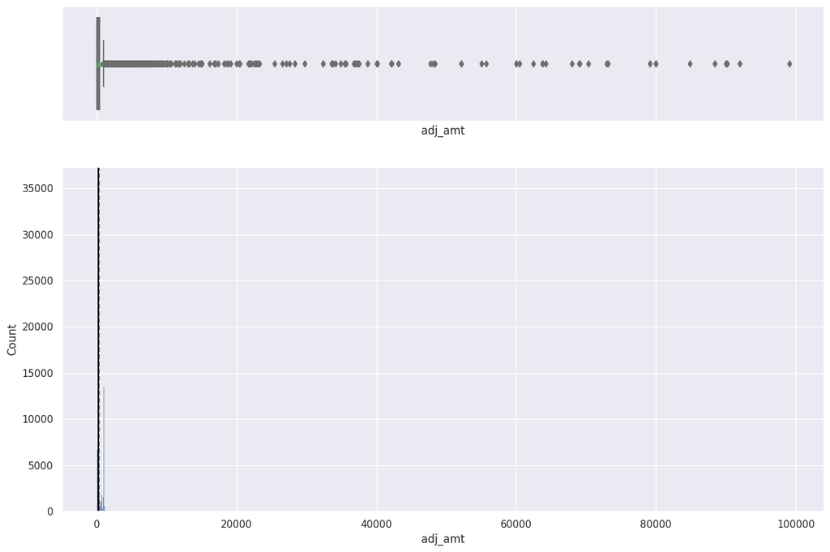

```python
histogram_boxplot(pre_policy_claims, "adj_amt")
```

```python
# Handle outliers by capping at lower and upper thresholds
pre_policy_claims.loc[pre_policy_claims['adj_amt'] < lower_threshold, 'adj_amt'] = lower_threshold
pre_policy_claims.loc[pre_policy_claims['adj_amt'] > upper_threshold, 'adj_amt'] = upper_threshold

# Count outliers after capping
pre_policy_claims_outlier_count_capped = pre_policy_claims[
    (pre_policy_claims['adj_amt'] < lower_threshold) | (pre_policy_claims['adj_amt'] > upper_threshold)
].shape[0]

# Verify the number of outliers after capping
print("Number of outliers in adj_amt pre_policy_claims (after capping):", pre_policy_claims_outlier_count_capped)
```

```
Number of outliers in adj_amt pre_policy_claims (after capping): 0
```

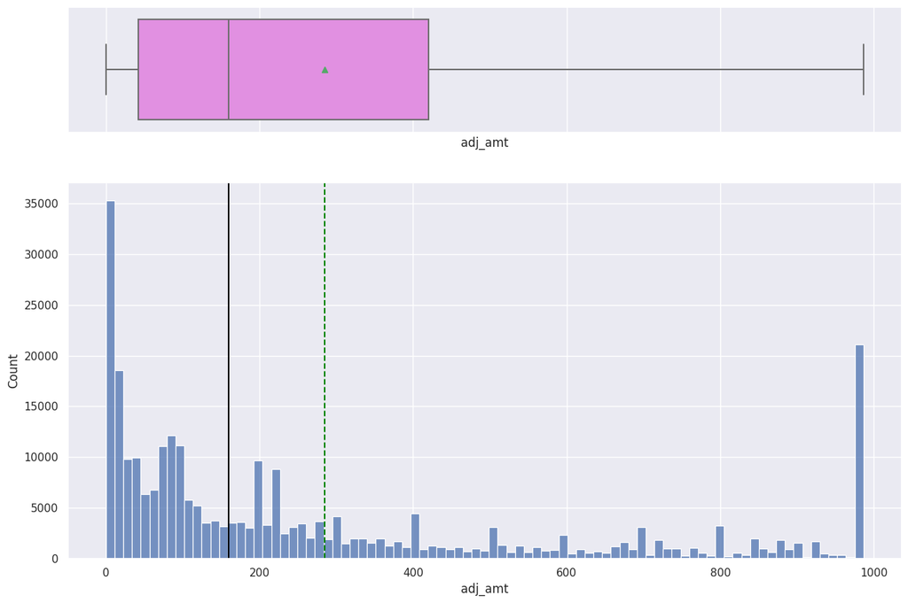

```python
histogram_boxplot(pre_policy_claims, "adj_amt")
```

```python
Q1 = post_policy_claims['adj_amt'].quantile(0.25)
Q3 = post_policy_claims['adj_amt'].quantile(0.75)
IQR = Q3 - Q1
lower_threshold = Q1 - 1.5 * IQR
upper_threshold = Q3 + 1.5 * IQR

# Identify outliers
post_policy_claims_outliers = post_policy_claims[
    (post_policy_claims['adj_amt'] < lower_threshold) | (post_policy_claims['adj_amt'] > upper_threshold)
]

# Count outliers
post_policy_claims_outlier_count = post_policy_claims_outliers.shape[0]

print("Number of outliers in adj_amt post_policy_claims:", post_policy_claims_outlier_count)
```

```
Number of outliers in adj_amt post_policy_claims: 1043
```

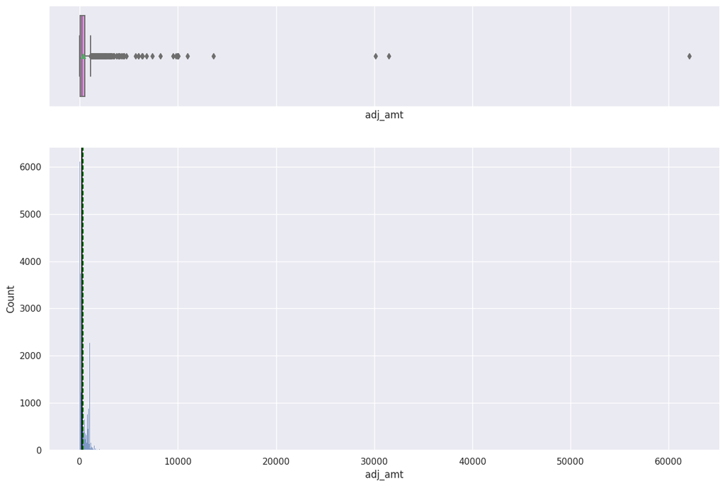

```python
histogram_boxplot(post_policy_claims, "adj_amt")
```

```python
# Handle outliers by capping at lower and upper thresholds
post_policy_claims.loc[post_policy_claims['adj_amt'] < lower_threshold, 'adj_amt'] = lower_threshold
post_policy_claims.loc[post_policy_claims['adj_amt'] > upper_threshold, 'adj_amt'] = upper_threshold

# Count outliers after capping
post_policy_claims_outlier_count_capped = post_policy_claims[
    (post_policy_claims['adj_amt'] < lower_threshold) | (post_policy_claims['adj_amt'] > upper_threshold)
].shape[0]

print("Number of outliers in adj_amt post_policy_claims (after capping):", post_policy_claims_outlier_count_capped)
```

```
Number of outliers in adj_amt post_policy_claims (after capping): 0
```

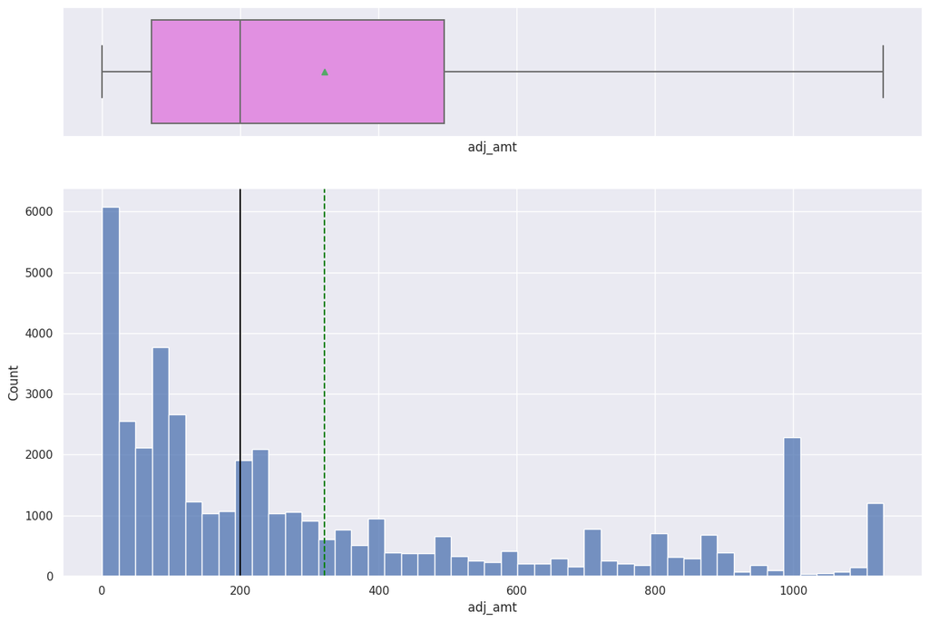

```python
histogram_boxplot(post_policy_claims, "adj_amt")
```

```python
Q1 = reimbursements_pre_policy['benefit_amount'].quantile(0.25)
Q3 = reimbursements_pre_policy['benefit_amount'].quantile(0.75)
IQR = Q3 - Q1
lower_threshold = Q1 - 1.5 * IQR
upper_threshold = Q3 + 1.5 * IQR

# Identify outliers
reimbursements_pre_policy_outliers = reimbursements_pre_policy[
    (reimbursements_pre_policy['benefit_amount'] < lower_threshold) | (reimbursements_pre_policy['benefit_amount'] > upper_threshold)
]

# Count outliers
reimbursements_pre_policy_outlier_count = reimbursements_pre_policy_outliers.shape[0]

print("Number of outliers in benefit_amount reimbursements_pre_policy:", reimbursements_pre_policy_outlier_count)
```

```
Number of outliers in benefit_amount reimbursements_pre_policy: 579
```

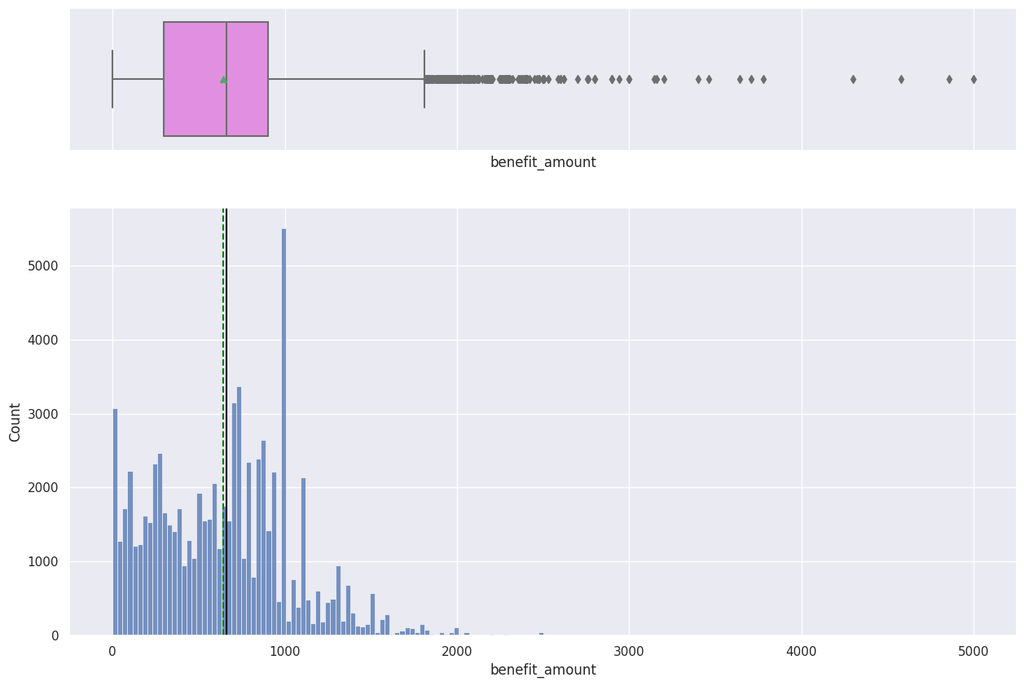

```python
histogram_boxplot(reimbursements_pre_policy, "benefit_amount")
```

```python
# Handle outliers by capping at lower and upper thresholds
reimbursements_pre_policy.loc[reimbursements_pre_policy['benefit_amount'] < lower_threshold, 'benefit_amount'] = lower_threshold
reimbursements_pre_policy.loc[reimbursements_pre_policy['benefit_amount'] > upper_threshold, 'benefit_amount'] = upper_threshold

# Count outliers after capping
reimbursements_pre_policy_outlier_count_capped = reimbursements_pre_policy[
    (reimbursements_pre_policy['benefit_amount'] < lower_threshold) | (reimbursements_pre_policy['benefit_amount'] > upper_threshold)
].shape[0]

print("Number of outliers in benefit_amount reimbursements_pre_policy (after capping):", reimbursements_pre_policy_outlier_count_capped)
```

```
Number of outliers in benefit_amount reimbursements_pre_policy (after capping): 0
```

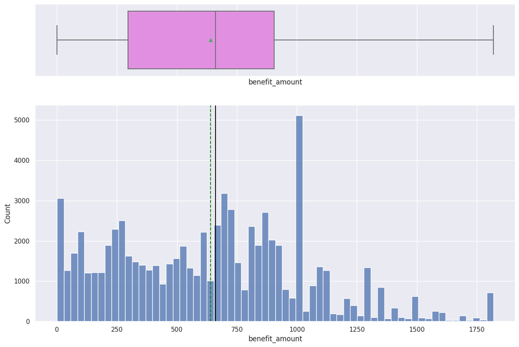

```python
histogram_boxplot(reimbursements_pre_policy, "benefit_amount")
```

```python
Q1 = reimbursements_post_policy['benefit_amount'].quantile(0.25)
Q3 = reimbursements_post_policy['benefit_amount'].quantile(0.75)
IQR = Q3 - Q1
lower_threshold = Q1 - 1.5 * IQR
upper_threshold = Q3 + 1.5 * IQR

# Identify outliers
reimbursements_post_policy_outliers = reimbursements_post_policy[
    (reimbursements_post_policy['benefit_amount'] < lower_threshold) | (reimbursements_post_policy['benefit_amount'] > upper_threshold)
]

# Count outliers
reimbursements_post_policy_outlier_count = reimbursements_post_policy_outliers.shape[0]

print("Number of outliers in benefit_amount reimbursements_post_policy:", reimbursements_post_policy_outlier_count)
```

```
Number of outliers in benefit_amount reimbursements_post_policy: 317
```

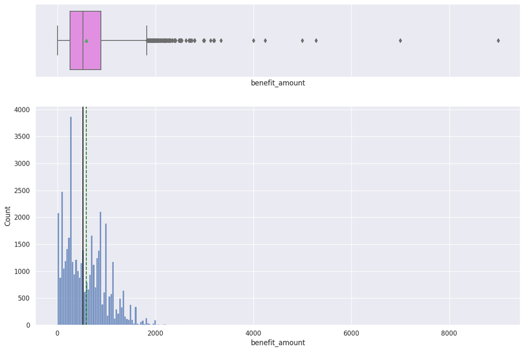

```python
histogram_boxplot(reimbursements_post_policy, "benefit_amount")
```

```python
# Handle outliers by capping at lower and upper thresholds
reimbursements_post_policy.loc[reimbursements_post_policy['benefit_amount'] < lower_threshold, 'benefit_amount'] = lower_threshold
reimbursements_post_policy.loc[reimbursements_post_policy['benefit_amount'] > upper_threshold, 'benefit_amount'] = upper_threshold

# Count outliers after capping
reimbursements_post_policy_outlier_count_capped = reimbursements_post_policy[
    (reimbursements_post_policy['benefit_amount'] < lower_threshold) | (reimbursements_post_policy['benefit_amount'] > upper_threshold)
].shape[0]

print("Number of outliers in benefit_amount reimbursements_post_policy (after capping):", reimbursements_post_policy_outlier_count_capped)
```

```
Number of outliers in benefit_amount reimbursements_post_policy (after capping): 0
```

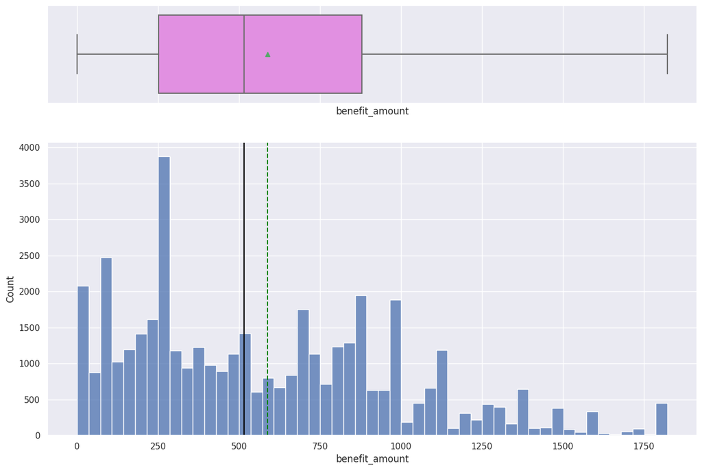

```python
histogram_boxplot(reimbursements_post_policy, "benefit_amount")
```